# Short Questions to Analyzing the NYC Subway Dataset

## Section 1. Statistical Test

### 1.2 Why is this statistical test applicable to the dataset? In particular, consider the assumptions that the test is making about the distribution of ridership in the two samples.

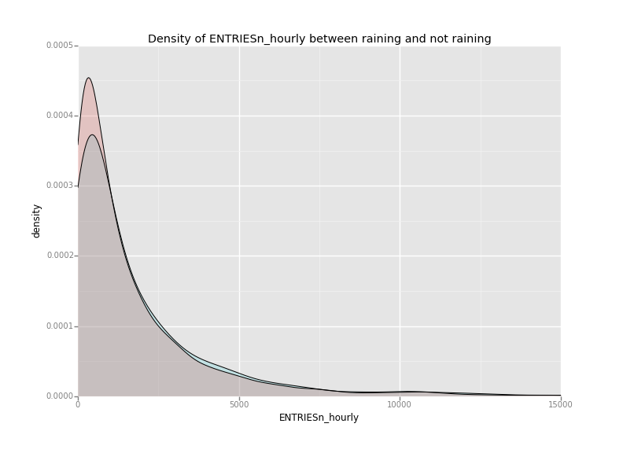

```python
%matplotlib inline
from ggplot import *
import pandas as pd
raw_data=pd.read_csv('turnstile_weather_v2.csv')
data_test=raw_data[['ENTRIESn_hourly','rain']]
plot=ggplot(data_test,aes(x='ENTRIESn_hourly', fill='rain'))+geom_density(alpha=0.25)+ ylab('density')+\
     ggtitle('Density of ENTRIESn_hourly between raining and not raining')+ xlim(0, 15000)
print(plot)
```

The figure shows strongly skewness, so maybe we should consider non-parametric test.

### 1.3 What results did you get from this statistical test? These should include the following numerical values: p-values, as well as the means for each of the two samples under test.

```python
import numpy as np
raw_data=pd.read_csv('turnstile_weather_v2.csv')
data_test=raw_data[['ENTRIESn_hourly','rain']]
with_rain_mean=np.mean(data_test[data_test['rain']==1]['ENTRIESn_hourly'])
without_rain_mean=np.mean(data_test[data_test['rain']==0]['ENTRIESn_hourly'])
print('The mean ENTRIESn_hourly with rain is '+str(with_rain_mean))
print('The mean ENTRIESn_hourly without rain is '+str(without_rain_mean))
x=data_test[data_test['rain']==1]['ENTRIESn_hourly']
y=data_test[data_test['rain']==0]['ENTRIESn_hourly']
u, prob=scipy.stats.mannwhitneyu(x,y)
m_u = len(x)*len(y)/2
sigma_u = np.sqrt(len(x)*len(y)*(len(x)+len(y)+1)/12)
z = (u - m_u)/sigma_u
pval = 2*scipy.stats.norm.cdf(z)
print('The p-value='+str(pval))
```

```
The mean ENTRIESn_hourly with rain is 2028.19603547
The mean ENTRIESn_hourly without rain is 1845.53943866
The p-value=5.48269387142e-06
```

Base on p-value, reject the null hypothesis

### 1.4 What is the significance and interpretation of these results?

Base on the test result, there is no enough evidence to support that the two distribution are equal and the mean ENTRIESn_hourly with rain  
is larger than the mean ENTRIESn_hourly without rain, we prefer more people ride the subway when it is raining versus when it is not raining.

## Section 2. Linear Regression

### 2.1 What approach did you use to compute the coefficients theta and produce prediction for ENTRIESn_hourly in your regression model:

#### a. Gradient descent (as implemented in exercise 3.5)

#### c. Or something different?

2. OLS using Statsmodels

### 2.2 What features (input variables) did you use in your model? Did you use any dummy variables as part of your features?

- UNIT and rain
- We treat UNIT as dummy variables

### 2.3 Why did you select these features in your model? We are looking for specific reasons that lead you to believe that the selected features will contribute to the predictive power of your model.

I choose feature by my intuition, the different station may make influence to numbers of people ride the subway and rain variable is also considerated

### 2.4 What are the coefficients (or weights) of the non-dummy features in your linear regression model?

```python
import numpy as np
import pandas as pd
import scipy
import statsmodels.api as sm
raw_data=pd.read_csv('turnstile_weather_v2.csv')
dummy_units=pd.get_dummies(raw_data['UNIT'], prefix='unit')
features=raw_data[['rain']].join(dummy_units)
values=raw_data[['ENTRIESn_hourly']]
m = len(values)
features['ones'] = np.ones(m)
features_array=np.array(features)
values_array = np.array(values).flatten()
X=features_array
Y=values_array
model = sm.OLS(Y,X).fit()
print('The coefficient of rain is '+str(model.params[0]))
```

```
The coefficient of rain is 173.959768089
```

### 2.5 What is your model’s R2 (coefficients of determination) value?

```python
print('R2: ', model.rsquared)
```

```
R2:  0.375820501086
```

### 2.6 What does this R2 value mean for the goodness of fit for your regression model? Do you think this linear model to predict ridership is appropriate for this dataset, given this R2 value?

- There is 37.6% variance of response can be explained by the features in the model
- I think the result is not bad, R-squared is just a reference of the model fitting, it is hard to say the model is right or wrong by R-squared

## Section 3. Visualization

### 3.1 One visualization should contain two histograms: one of ENTRIESn_hourly for rainy days and one of ENTRIESn_hourly for non-rainy days.

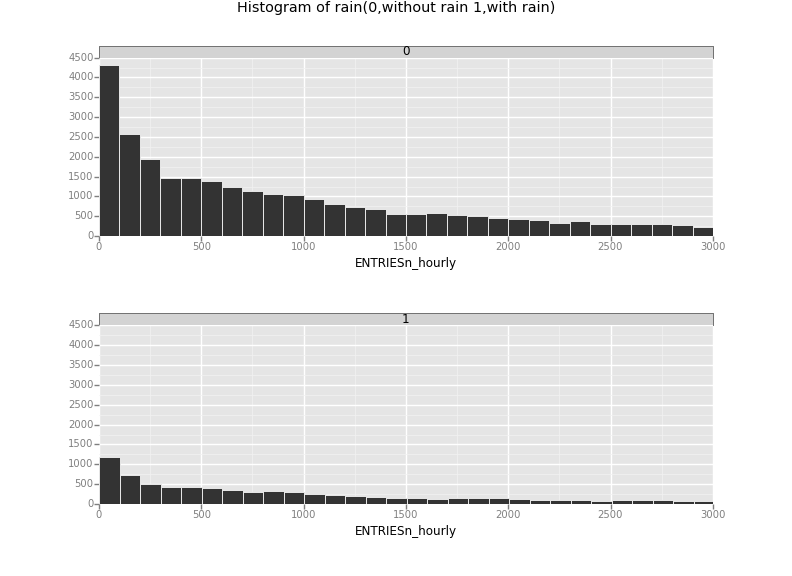

```python
%matplotlib inline
from ggplot import *
import pandas as pd
raw_data=pd.read_csv('turnstile_weather_v2.csv')
data_test=raw_data[['ENTRIESn_hourly','rain']]
plot=ggplot(data_test,aes(x='ENTRIESn_hourly'))+geom_histogram(binwidth=100)+facet_wrap("rain")+xlim(0, 3000)+ylim(0, 4500)+ \
ggtitle("Histogram of rain(0,without rain 1,with rain)")
print(plot)
```

### 3.2 One visualization can be more freeform. Some suggestions are:

- Ridership by time-of-day

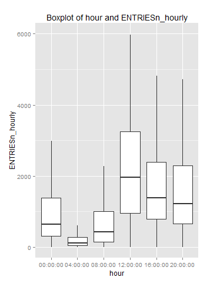

```python
from IPython.display import Image
Image(filename='Rplot01.png')
```

More people ride the subway after noon

- Ridership by day-of-week

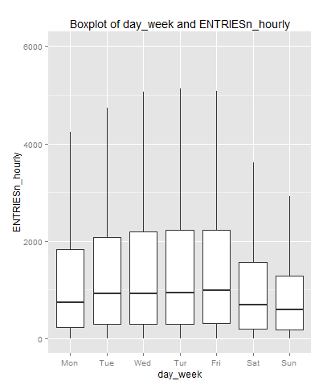

```python
from IPython.display import Image
Image(filename='Rplot02.png')
```

Less people ride the subway at weekend

## Section 4. Conclusion

### 4.2 What analyses lead you to this conclusion? You should use results from both your statistical tests and your linear regression to support your analysis.

If we just consider variable ENTRIESn_hourly when rain=0 versus rain=1, by Mann-Whitney U-Test we perform in section 1, we get very small p-value, in section 2 the coefficient of rain is lager than zero, in other word, when rain variable from 0(not raining) to 1(raing) and other feature are fix, the response will increase at average, these results lead us to support more people ride the NYC subway.

## Section 5. Reflection

### 5.1 Please discuss potential shortcomings of the methods of your analysis, including:

- Dataset

There are slightly difference between subway station site and weather station site, it may cause some error

- Linear regression model

I don't perform the statistical test about the coefficient in section 2, the result is more convincing after test.

- Statistical test

Other non-parametric test may take into consideration, it can ensure the correctness of the result

## 5.2 (Optional) Do you have any other insight about the dataset that you would like to share with us?

The variables latitude and longitude provide no further information, because the same unit have same latitude and longitude